# R u Ready? FS2026 | Psychologie der Digitalisierung - Einheit 14

Sandra Grinschgl, Laura Hirt, Lars Schilling

## R u Ready? Reproduzierbare Datenaufbereitung und -analyse mit R

FS 2026  
**LV-Leitung**: Dr. Sandra Grinschgl / MSc. Laura Hirt  
**Tutor**: BSc. Lars Schilling  
**14. Einheit**, 27.05.2026

## Heute:

[figure not shown]

## Congrats!

[figure not shown]

## 1. Offene Fragen zu HÜ 3 / Hands-On 7?

## 3. Gruppe Laura: Wettbewerb Cheatsheet

**So stimmt ihr ab:**

[figure not shown]

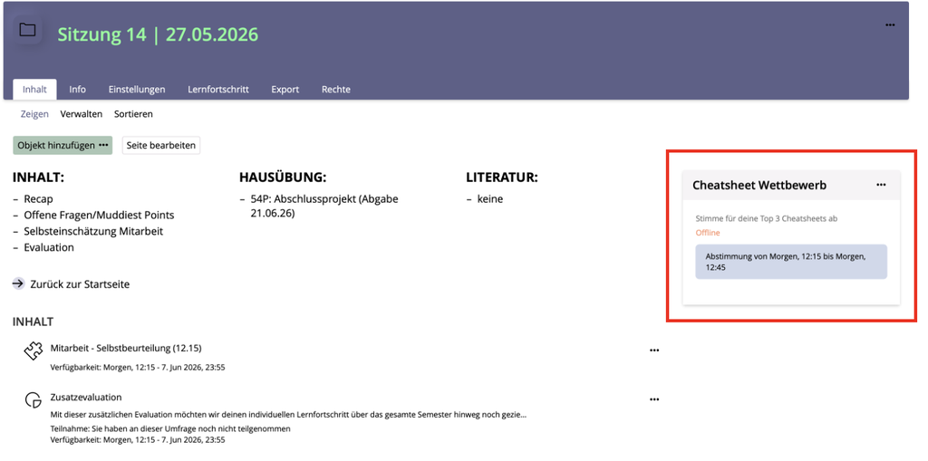

# Die zwei Zusatzpunkte gehen an …

## **4. Abschlussarbeit**

#### Repetition: relative Pfade mit `here()`

Relative Pfade starten im Projektordner (dort, wo `ryouready.Rproj` liegt)

Es gibt zwei Varianten:

**Variante 1: relativer Pfad von Hand**

```r
dat_pct <- read.csv("data/raw/data_pct.csv")
```

**Logik:**

```
Projektordner
└── data
    └── raw
        └── data_pct.csv
```

## **4. Abschlussarbeit**

#### Repetition: relative Pfade mit `here()`

**Variante 2: relativer Pfad mit `here()`**

```r
dat_pct <- read.csv(
  here::here("data", "raw", "data_pct.csv")
)
```

**Logik:**

```
here::here("data", "raw", "data_pct.csv")
```

baut automatisch den passenden Pfad aus den einzelnen Teilen:

```
Projektordner/data/raw/data_pct.csv
```

## **4. Abschlussarbeit**

#### Repetition: Anpassung des YAML-Headers

**4.5 Formelle Vorgaben:** Warn- und Fehlermeldungen werden nicht unterdrückt, sondern transparent dargestellt und interpretiert…

→ Der YAML-Header muss angepasst werden!

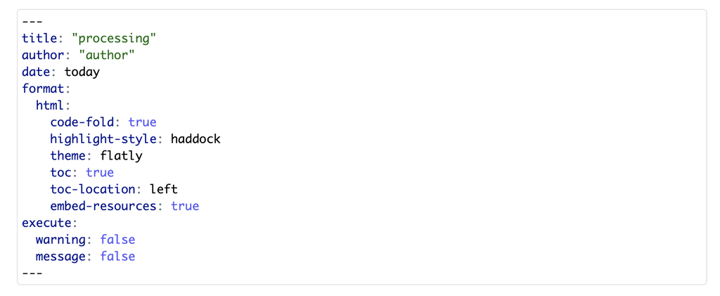

## **4. Abschlussarbeit**

#### Verlängerung der Abgabefrist

Die Abgabefrist der Abschlussarbeit wurde um eine Woche verlängert.

→ Deadline ist neu der `21.06.2026, 23:55 Uhr`

## **4. Abschlussarbeit**

#### Feedback-Möglichkeiten zur Arbeit

- Wenn du individuelles Feedback zu deiner Abschlussarbeit möchtest
- Infos zur genauen Zusammensetzung deiner Note
- Oder anderen Seminar-bezogenen Dinge

👉 Selbstständig bei uns (laura.hirt@unibe.ch / sandra.grinschgl@unibe.ch) melden!

## **5. Recap**

#### **Konzeptionelle Kompetenzen**

- Replikationskrise und ihre Ursachen
- Open-Science-Praktiken
- Möglichkeiten zur Steigerung der Transparenz, z.B. durch **Datenanalysepläne** und **Codebooks**
- Grundlagen des FAIR Forschungsdatenmanagement – PsychDS

## **5. Recap**

#### **Praktische Kompetenzen**

- RStudio und Pakete installieren, laden und nutzen
- Anlegen von Projekten; Einführung in die RStudio- und Quarto-Benutzeroberfläche
- Coding-Basics: z.B. Verktoren, Operatoren, Objekte, Working Directory
- Stilregeln und systematische Fehlersuche (Error Detection) in R
- Daten importieren und exportieren
- Manipulation von Data Frames, Matrizen und Listen
- Daten zwischen Wide- und Long-Format umwandeln
- Verwendung des Pipe-Operators `%>%` oder `|>`

## **5. Recap**

#### **Praktische Kompetenzen**

- Umgang mit fehlenden Werten
- Filtern, Manipulation und Gruppierung von Datensätzen (Data Wrangling)
- Umkodieren von Variablen
- Berechnen von deskriptiven Statistiken (z. B. Mittelwerte, Standardabweichungen, Schiefe, Kurtosis)
- Überprüfung der Normalverteilung inkl. visueller Darstellung der Residuen
- Berechnung von Skalenreliabilitäten
- Datenvisualisierungen
- Korrelationen und Regressionen
- t-Tests und ANOVAs (inkl. Überprüfung der Voraussetzungen und Berechnung von Effektstärken)

## **5. Recap**

#### **Was dieses Seminar nicht leisten konnte**

- vollständige Wiederholung/Auffrischung der Statistik
- „Kochbuch“ für jede mögliche Masterarbeit
- vollständiges Cheatsheet mit „allen Funktionen“ in R
- komplexe statistische Modelle, z.B. Strukturgleichungsmodelle oder Mehrebenenmodelle
  - Siehe weiterführende Methodenseminare der Abteilungen Gesundheitspsychologie und Psychologie der Digitalisierung

## **6. Recap: Evaluation & Abschluss**

#### **Selbstevaluation der Mitarbeit**

- **14 Punkte Insgesamt**
- **7 Punkte dürft ihr euch selbst vergeben**

👉Umfrage auf ILIAS (Woche 14)!

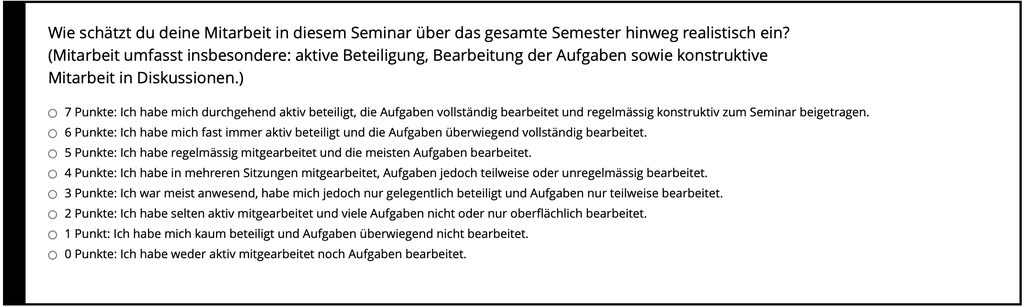

## **6. Recap: Evaluation & Abschluss**

#### **Seminarevaluation: Standardfragebogen der Uni**

**Bitte verwendet den Link, welcher zu eurer Gruppe gehört!**

## Gruppe Laura 12:15

https://scanserveruls.unibe.ch/evasys/public/online/index/index?online_php=&pswd=SMKNC&ONLINEID=157540934219219477945284313175345624895804

[figure not shown]

## Gruppe Sandra 16:15

[figure not shown]

## **6. Recap: Evaluation & Abschluss**

#### **Zusatzfragebogen**

**Auf ILIAS in Ordner EH14**

[figure not shown]

## **Weiterführende Ressourcen**

[figure not shown]

## Methodenberatung

[figure not shown]

## Schöne Sommerferien und alles Gute!

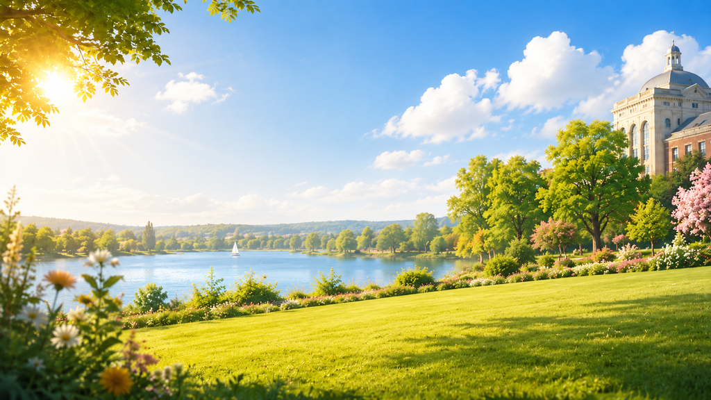